# PROJET DE SESSION : ANALYSE DU PROGRAMME CULTURE ET CITOYENNETÉ QUÉBÉCOISE (CCQ)

# Par Léonie Asselin

## 1. Question de recherche

Le programme de CCQ fournit-il aux jeunes non politisés les ressources nécessaires pour développer une compréhension minimale de la politique et participer à la vie citoyenne ?

## 2. Revue de littérature

Dans les démocraties occidentales, les jeunes sont souvent accusés d’être désengagés de la vie politique. Ces jeunes apolitisés ne constituent pas un groupe homogène, puisque les obstacles et la motivation à la participation politique varient selon les individus. Parmi ces jeunes se trouve notamment le groupe des démunis. Ceux-ci se caractérisent par leur manque de connaissances et de ressources politiques. Ainsi, la non-participation de ce groupe de jeunes s’explique par leur incompréhension des systèmes politiques québécois et canadiens (Mahéo et al., 2012).

Dans plusieurs pays occidentaux, dont le Canada, les cours d’éducation à la citoyenneté contribuent à augmenter l’intérêt politique, les connaissances politiques ainsi que l’engagement civique et politique. Ces conséquences sont exacerbées lorsque les élèves sont encouragés à débattre en classe, au sein d’un climat de classe ouverte (Fortier-Chouinard, 2021). Or, les cours centrés uniquement sur des contenus formels, tels que la structure de l’État et les branches du gouvernement, n’ont qu’un très faible gain sur la participation politique. En effet, ces notions augmentent le niveau de connaissance, mais pas nécessairement l’engagement politique (Kahne et al., 2006).

Le gouvernement du Québec s’est doté d’un nouveau cours d’éducation à la citoyenneté, Culture et citoyenneté québécoise (CCQ). Ce dernier, obligatoire pour tous les élèves, est implanté dans toutes les écoles sur le territoire de la province depuis août 2023. Le programme est vaste, diversifié et touche à plusieurs notions. Plusieurs de celles-ci visent l’acquisition de connaissances sur les institutions politiques et sur la citoyenneté (Programme de formation de l’école québécoise. Enseignement secondaire, 2023; Programme de formation de l’école québécoise. Enseignement primaire, 2023).

## 3. Hypothèse

Le cours de Culture et citoyenneté québécoise au primaire et au secondaire s’inscrit davantage dans l’enseignement de contenus formels, ce qui donnerait peu de gain sur la participation politique. Cet effet pourrait être amélioré si les élèves sont amenés à débattre en classe, mais cette pratique dépend du choix discrétionnaire de l’enseignant. Ainsi, le cours de CCQ ne permet pas nécessairement aux jeunes non-politisés d’acquérir les ressources politiques nécessaires à une compréhension minimale de la vie politique et à la participation citoyenne.

## 4. Analyse et visualisation des données

Le code ci-dessous présente la méthodologie complète de l’analyse lexicale, de la collecte des données à la visualisation des résultats (Tableau 1 et Figure 1).

```r
# --- 1. PRÉPARATION DE L'ENVIRONNEMENT ET CHARGEMENT DES DONNÉES ---

# Chargement des librairies (Installation des packages laissée commentée)
library(pdftools) # Pour l'extraction PDF
library(quanteda) # Pour le nettoyage et l'analyse textuelle
library(reshape2) # Pour la transformation des données (melt)
```

```r
library(ggplot2) # Pour la visualisation graphique
library(tibble) # Pour la gestion du data.frame (tibble)
# Définition des chemins de fichiers (DOIVENT ÊTRE DANS LE MÊME DOSSIER QUE .RMD)
# Si les PDF sont dans le même dossier, utilisez les chemins courts ci-dessous:
chemin_primaire <- "C:/Users/leoni/OneDrive/Bureau/Université/Maîtrise/PFEQ-culture-citoyennete-quebecoise-Primaire.pdf"
chemin_secondaire <- "C:/Users/leoni/OneDrive/Bureau/Université/Maîtrise/PFEQ-culture-citoyennete-quebecoise-Secondaire.pdf"

# Lecture des PDF
# (Si vous utilisez les chemins longs de votre ordinateur, la compilation peut échouer)
primaire_pdf <- pdf_text(chemin_primaire)
```

[output not shown]

[output not shown]

[output not shown]

```r
secondaire_pdf <- pdf_text(chemin_secondaire)
```

[output not shown]

[output not shown]

```r
# --- 2. EXTRACTION DES 4 CORPUS ---

# PRIMAIRE
pages_primaire_contenus <- c(25:63)
primaire_contenus <- paste(primaire_pdf[pages_primaire_contenus], collapse = " ")
primaire_eval <- paste(primaire_pdf[16:24], collapse = " ")

# SECONDAIRE
pages_secondaire_contenus <- c(27:82)
secondaire_contenus <- paste(secondaire_pdf[pages_secondaire_contenus], collapse = " ")
secondaire_eval <- paste(secondaire_pdf[16:26], collapse = " ")


# --- 3. NETTOYAGE LINGUISTIQUE ET CRÉATION DE LA DFM ---

# Rassemblement des 4 corpus de texte brut
data_corpus <- data.frame(
  text = c(primaire_contenus, primaire_eval, secondaire_contenus, secondaire_eval),
  programme = c("Primaire", "Primaire", "Secondaire", "Secondaire"),
  type = c("Contenus", "Evaluation", "Contenus", "Evaluation"),
  stringsAsFactors = FALSE
)
corpus_ccq <- corpus(data_corpus)

# Définition des mots vides en français
mots_vides_fr <- stopwords("french")

# Nettoyage (Tokenization, suppression du bruit et stemming)
tokens_ccq <- tokens(corpus_ccq,
                     remove_numbers = TRUE,
                     remove_punct = TRUE,
                     remove_symbols = TRUE,
                     remove_separators = TRUE) %>%
  tokens_remove(pattern = "http*", valuetype = "glob") %>%
  tokens_remove(pattern = mots_vides_fr) %>%
  tokens_wordstem(language = "french")

# Création de la Document-Feature Matrix (DFM)
dfm_ccq <- dfm(tokens_ccq)


# --- 4. ANALYSE PAR DICTIONNAIRE ET QUANTIFICATION ---

# Dictionnaire de mots-clés (en racines - Stemming)
dictionnaire_ccq <- dictionary(list(
  Savoirs_Formels_Institutionnels = c("institu", "gouvern", "loi", "droit", "règl", "norm", "structur", "connaiss", "systèm", "concept"),
  Pratique_Pensee_Critique = c("particip", "dialogu", "débatt", "critiqu", "réfléch", "action", "engagement", "compét", "examin", "développ")
))

# Appliquer le dictionnaire à la matrice de mots (DFM)
dfm_analyse <- dfm_lookup(dfm_ccq, dictionnaire_ccq)
resultats_frequence <- convert(dfm_analyse, to = "data.frame")
resultats_frequence$programme <- data_corpus$programme
resultats_frequence$type <- data_corpus$type


# --- 5. CALCUL DES RATIOS ET VISUALISATION ---

taille_des_corpus <- ntoken(dfm_ccq)
resultats_long <- reshape2::melt(resultats_frequence,
                                 id.vars = c("programme", "type"),
                                 variable.name = "categorie",
                                 value.name = "frequence_brute")

resultats_long <- merge(resultats_long, data.frame(
  programme = data_corpus$programme,
  type = data_corpus$type,
  taille_corpus = taille_des_corpus,
  stringsAsFactors = FALSE
))

# CONVERSION EXPLICITE
resultats_long$frequence_brute <- as.double(resultats_long$frequence_brute)
resultats_long$taille_corpus <- as.double(resultats_long$taille_corpus)

# Calcul du RATIO
resultats_long$ratio_frequence <- resultats_long$frequence_brute / resultats_long$taille_corpus

# --- AFFICHAGE DES RÉSULTATS ---

# Tableau 1: Ratios de Fréquence (Résultats Clés)
print("Tableau des Ratios de Fréquence (Résultats Clés) :")
```

```
## [1] "Tableau des Ratios de Fréquence (Résultats Clés) :"
```

```r
print(resultats_long)
```

```
##     programme       type                       categorie frequence_brute
## 1    Primaire   Contenus                          doc_id              NA
## 2    Primaire   Contenus Savoirs_Formels_Institutionnels              87
## 3    Primaire   Contenus        Pratique_Pensee_Critique              62
## 4    Primaire Evaluation                          doc_id              NA
## 5    Primaire Evaluation Savoirs_Formels_Institutionnels              12
## 6    Primaire Evaluation        Pratique_Pensee_Critique              42
## 7  Secondaire   Contenus                          doc_id              NA
## 8  Secondaire   Contenus Savoirs_Formels_Institutionnels             229
## 9  Secondaire   Contenus        Pratique_Pensee_Critique              97
## 10 Secondaire Evaluation                          doc_id              NA
## 11 Secondaire Evaluation Savoirs_Formels_Institutionnels              35
## 12 Secondaire Evaluation        Pratique_Pensee_Critique              49
##    taille_corpus ratio_frequence
## 1           7547              NA
## 2           7547     0.011527759
## 3           7547     0.008215185
## 4           1866              NA
## 5           1866     0.006430868
## 6           1866     0.022508039
## 7          11431              NA
## 8          11431     0.020033243
## 9          11431     0.008485697
## 10          2528              NA
## 11          2528     0.013844937
## 12          2528     0.019382911
```

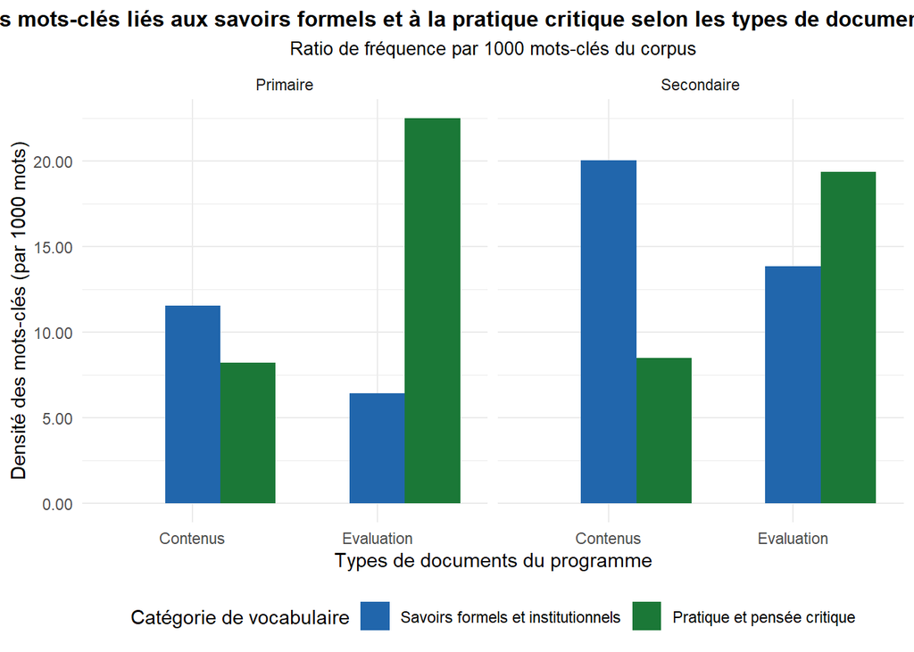

```r
# Figure 1: Visualisation (Le Graphique)
ggplot(resultats_long, aes(x = type, y = ratio_frequence, fill = categorie)) +
  geom_bar(stat = "identity", position = "dodge") +
  facet_wrap(~ programme) +
  labs(
    title = "Densité des mots-clés liés aux savoirs formels et à la pratique critique selon les types de documents du programme",
    subtitle = "Ratio de fréquence par 1000 mots-clés du corpus",
    x = "Types de documents du programme",
    y = "Densité des mots-clés (par 1000 mots)",
    fill = "Catégorie de vocabulaire"
  ) +
  scale_fill_manual(
    name = "Catégorie de vocabulaire",
    values = c(
      "Savoirs_Formels_Institutionnels" = "#2166AC",
      "Pratique_Pensee_Critique" = "#1B7837"
    ),
    labels = c(
      "Savoirs_Formels_Institutionnels" = "Savoirs formels et institutionnels",
      "Pratique_Pensee_Critique" = "Pratique et pensée critique"
    )
  ) +
  scale_y_continuous(labels = scales::number_format(accuracy = 0.01, scale = 1000)) +
  theme_minimal() +
  theme(
    plot.title = element_text(hjust = 0.5, face = "bold", size = 12),
    plot.subtitle = element_text(hjust = 0.5, size = 10),
    axis.title.x = element_text(size = 11),
    axis.title.y = element_text(size = 11),
    legend.position = "bottom"
  )
```

## 5. Discussion

### 5.1 Interprétation des résultats

Au primaire, on voit que les contenus mettent l’accent sur les savoirs formels et factuels, tandis que les évaluations mettent davantage l’accent sur les savoirs-faire de la réflexion éthique et de la pensée critique. Ainsi, le programme exige clairement des enseignants qu’ils développent et évaluent la pratique du dialogue, du jugement critique et de la délibération chez les jeunes élèves.

### 5.2 Outils numériques mobilisés

Elicit et Zotero ont été utilisés pour la section de la revue de littérature. Elicit a notamment été sélectionné pour la recherche de sources. Ce choix a été fait principalement en fonction des besoins du travail, soit de sélectionner quelques sources importantes et utiles pour effectuer une courte revue de littérature. Le choix d’Elicit a également été fait pour sa popularité dans le champ de la science politique et des sciences humaines en général, de son accessibilité et de sa compatibilité avec Zotero, qui, pour sa part, a servi à l’organisation des sources et à la rédaction de la bibliographie. Zotero a également été choisi en fonction de sa popularité en sciences sociales, de son accessibilité et de sa compatibilité avec Elicit.

Les fichiers PDF des programmes pour la collecte de résultats ont, quant à eux, été trouvés à l’aide d’une recherche Google sur le site du gouvernement.

RStudio a été sélectionné pour l’étape de l’analyse des résultats en fonction de sa flexibilité, de son adaptabilité, de sa communauté d’utilisateurs, de sa popularité en sciences sociales, de sa transparence, de sa réplicabilité et de sa philosophie du logiciel libre.

Finalement, Gemini Pro a été utilisé pour la correction du français et pour l’aide à la création du code d’analyse effectué sur RStudio. Toutes les réponses de l’intelligence artificielle ont été vérifiées afin d’éviter les erreurs. Gemini Pro a été choisi notamment pour son accessibilité à la communauté étudiante.

## 6. Bibliographie

Fortier-Chouinard, A. (2021). Éducation à la citoyenneté et politisation des jeunes au Québec : Perspectives d’enseignant⋅e⋅s. Revue des sciences de l’éducation, 46(3), 95‑124. https://doi.org/10.7202/1075989a

Kahne, J., Chi, B., & Middaugh, E. (2006). Building Social Capital for Civic and Political Engagement : The Potential of High-School Civics Courses. Canadian Journal of Education / Revue Canadienne de l’éducation, 29(2), 387. https://doi.org/10.2307/20054169

Mahéo, V.-A., Dejaeghere, Y., & Stolle, D. (2012). La non-participation politique des jeunes : Une étude des barrières temporaires et permanentes de l’engagement. Canadian Journal of Political Science, 45(2), 405‑425. https://doi.org/10.1017/S0008423912000388

Programme de formation de l’école québécoise. Enseignement primaire : Programme Culture et citoyenneté québécoise. (2023). Ministère de l’éducation.

Programme de formation de l’école québécoise. Enseignement secondaire : Programme culture et citoyenneté québécoise. (2023). Ministère de l’éducation.